# Statisik - Cheat Sheet

Afdeling 11

10/12/2019

# R Kommandoer

| Females(x) | 2474 | 2547 | 2830 | 3219 | 3429 | 3448 | 3677 | 3872 | 4001 | 4116 |
| --- | --- | --- | --- | --- | --- | --- | --- | --- | --- | --- |
| Males(y) | 2844 | 2863 | 2963 | 3239 | 3379 | 3449 | 3582 | 3926 | 4151 | 4356 |

```r
x <- c(2474, 2547, 2830, 3219, 3429, 3448, 3677, 3872, 4001, 4116)
y <- c(2844, 2863, 2963, 3239, 3379, 3449, 3582, 3926, 4151, 4356)
```

## Symboler

**Mu (μ):** refers to a population mean; and **x̄**, to a sample mean

**Rho (Ρ)** refers to a population proportion that have a particular attribute; and **ρ**, refers to a sample proportion (population correlation coefficient based on all of the elements from a population)

*X* refers to a set population elements; and *x*, to a set of sample elements

*N* refers to a population size; and *n*, to a sample size

**Sigma (σ):** standard deviation of a population; and *s*, to the standard deviation of a sample

**Sigma<sup>2</sup> (σ<sup>2</sup>):** refers to the variance of a population

**Q** refers to the propotion of population elements that do not have a particular attribute, so Q = 1 - P.

**s<sup>2</sup>** refers to the variance of a sample

**q** refers to the proportion of sample elements that do not have a particular attribute, so q = 1 - p

**r** is the sample correlation coefficient based on all elements from a sample.

**B<sub>0</sub>** is the intercept constant in a population regression line.

**B<sub>1</sub>** is the regression coefficient (i.e. slope) in a population regression line

**R<sup>2</sup>** refers to the coefficient of determination

**b<sub>0</sub>** is the intercept constant in a sample regression line

**b<sub>1</sub>** refers to the regression coefficient in a sample regression line (i.e. slope)

**s<sub>b<sub>1</sub></sub>** refers to the refers to the standard error of the slope of a regression line

## Sample Mean

mean()

```r
mean(x)
```

```
## [1] 3361.3
```

```r
mean(y)
```

```
## [1] 3475.2
```

## Variance

var()

```r
var(x)
```

```
## [1] 344920.5
```

```r
var(y)
```

```
## [1] 283158.2
```

## Standard Deviation

sd()

```r
sd(x)
```

```
## [1] 587.2993
```

```r
sd(y)
```

```
## [1] 532.1261
```

## Quartiles / Quantile

quantile()

```r
quantile(x)
```

```
##      0%     25%     50%     75%    100%
## 2474.00 2927.25 3438.50 3823.25 4116.00
```

```r
quantile(y)
```

```
##   0%  25%  50%  75% 100%
## 2844 3032 3414 3840 4356
```

## Boxplot

boxplot()  
single

```r
boxplot(x, col = 2)
```

[figure not shown]

multiple

```r
boxplot(list(x,y), col = 2:3)
```

[figure not shown]

## Coefficient of variations

sd() / mean()  
Kan skrives sådan for at få direkte i procent:  
(sd() / mean())*100

```r
(sd(x)/mean(x))*100
```

```
## [1] 17.47239
```

```r
sd(y)/mean(y)
```

```
## [1] 0.153121
```

## Median

median()

```r
median(x)
```

```
## [1] 3438.5
```

```r
median(y)
```

```
## [1] 3414
```

## Sample Coveriance

cov()

```r
cov(x, y)
```

```
## [1] 301836.3
```

## Sample Correlation

cor()

```r
cor(x, y)
```

```
## [1] 0.9658227
```

## Binomial Distribution

### dbinom

```r
dbinom(4, size = 10, prob = 0.6)*100
```

```
## [1] 11.14767
```

I dette sammenhæng, er det chancen for succes, når man skal have præcis 4 succeser ud af 10 forsøg med en succes chance på 60%

### pbinom

```r
## P(X <= 5) 5 eller under successer
pbinom(5, size = 10, prob = 0.6)*100
```

```
## [1] 36.68967
```

```r
## P(X < 5) under 5 successer
pbinom(4, size = 10, prob = 0.6)*100
```

```
## [1] 16.62386
```

```r
## P(X > 4) over 4 successer
(1 - pbinom(4, size = 10, prob = 0.6))*100
```

```
## [1] 83.37614
```

```r
## P(X = 5) præcis 5 successer
(pbinom(5, size = 10, prob = 0.6) - pbinom(4, size = 10, prob = 0.6))*100
```

```
## [1] 20.06581
```

## Poisson Distribution

### dpois

```r
dpois(4, lambda  = 3)
```

```
## [1] 0.1680314
```

I dette sammenhæng, er det chancen for at få 4 events per interval, når gennemsnittet(mean) per interval er 3 events

### ppois

```r
## P(X <= 5)
ppois(5, lambda  = 3)
```

```
## [1] 0.9160821
```

```r
## P(X < 5)
ppois(4, lambda  = 3)
```

```
## [1] 0.8152632
```

```r
## P(X > 4)
1 - ppois(4, lambda  = 3)
```

```
## [1] 0.1847368
```

```r
## P(X = 5)
ppois(5, lambda  = 3) - ppois(4, lambda  = 3)
```

```
## [1] 0.1008188
```

# Opgaver

## Afhængige variabel og forklarende variabel i model

For at undersøge downloadhastigheden ved en arbejdsstation har man målt downloadtiderne (i sekunder) for 53 filer af forskellige størrelser ( m˚alt i MB). Downloadtiderne er gemt i vektorentime i R, mens de tilsvarende filstørrelser er gemt i vektoren size. Desuden er følgende kodeblevet kørt i R:

```
    logtime <- log(time)
    model1<- lm(logtime ~ size)
    summary(model1)

    ##
    ## Call:
    ## lm(formula = logtime ~ s ize )
    ##
    ## Residuals:
    ## Min 1Q Median 3Q Max
    ## -2.571 -0.673 0.132 0.745 2. 1 90
    ##
    ## Coefficients:
    ## Estimate Std. Error t value P r( > |t |)
    ## (Intercept) -0.109 0.482 -0.23 0.82
    ## size 0.127 0.023 5.50 1.2e-06 ***
    ## ---
    ## Signif. codes: 0 '***' 0.001 '**' 0.01 '*' 0.05 '.' 0.1 ' ' 1
    ##
    ## Residual standard error: 0.979 on 51 degrees of freedom
    ## Multiple R-squared: 0.372,Adjusted R-squared: 0.36
    ## F-statistic: 30.2 on 1 a nd 51 DF, p-va l ue : 1.25e-06
```

The statistical model given by model1 is a linear regression model of the form

```
Yi= β0+ β1xi+ εi,
```

where εi, i = 1, . . . , 53, are assumed to be independent and identically N(0, σ2) distributed

Identify the dependent variable and the explanatory variable in the model given by model1.

1. Download time is the dependent variable. File size is the explanatory variable
2. File size is the dependent varia b l e. The log arithm of download time is the explanatory variable
3. Download time is the explanatory variable. File size is the dependent variable.
4. **File size is the explanatory variable. The logarithm of download time is the dependent variable.**
5. As (the logarithm of) download time depends on file size, both file size and the logarithm of download size are dependent variables. There is no explanatory variable in the model.

### FACIT

The variable to the left of the tilde (∼) in the R code corresponds to the dependent variable Yi, while the variable to the right of the tilde corresponds to the explanatory variable xi

## 90% interval prediction (kender mean og var)

The following code was also executed in R:

```
    mean(size)

    ## [1] 20.088

    (53-1)*var(size)

    ## [1] 1807.6
```

Using the model given by model1 as a starting point, give a 90% prediction interval for the logarithm of the download time for a file of size 17 MB.

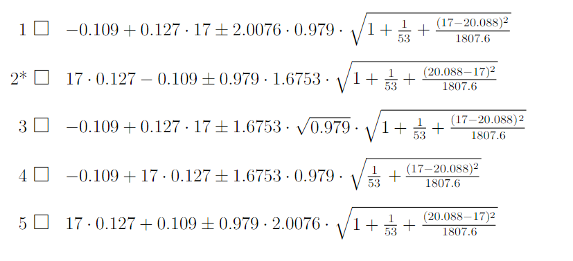

### FACIT

Use Method 5.18, equation (5-60). Note tha t 1.6753 is the 0.95 quantile of the t-distribution with 51 degrees of freedom, qt(0.95, df = 51) in R.

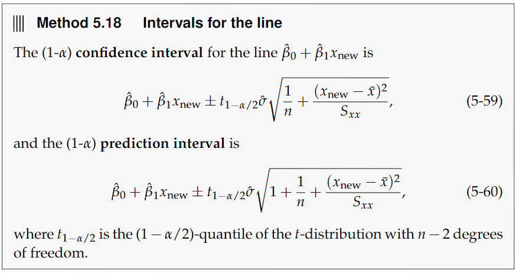

## Gennemsnit af histogram

**Fra Stackoverflow:** For each histogram bar, we start by multiplying the central x-value to the corresponding bar height. Each of these products corresponds to the sum of all values falling within each bar. Summing all products gives us the total sum of all values, and dividing it by the number of observations yields the mean

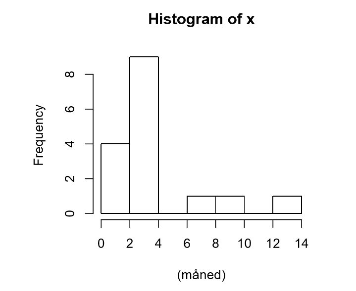

```
(4+27+7+9+13)/16 = 3.75
```

Dvs. at gennemsnittet af histogrammet er 3.75. Værdierne få’s ved at tage midter værdien af en søjle (f.eks. 1 er mellem 0-2) og så ganger den med søjlens højde (4) så 1*4 = 4, så lægger man dem sammen med næste søjle. I dette eksempel er næste søjle 9 høj, og ligger mellem 2-4 så vi ganger med 3: 9x3 = 27)

## Variansudregning når man kender antal og p

```
  μ = n ⋅ p
  σ2 = n ⋅ p ⋅ (1 - p)
```